# Assignment

```python
import pandas as pd
import numpy as np
import seaborn as sns
import matplotlib.pyplot as plt
from matplotlib.pyplot import figure
from sklearn.model_selection import train_test_split
from sklearn.linear_model import LinearRegression
from sklearn.metrics import mean_squared_error, r2_score
from math import sqrt
```

Loading the data file

```python
df = pd.read_csv('googleplaystore.csv')
```

```python
df.head()
```

|  | App | Category | Rating | Reviews | Size | Installs | Type | Price | Content Rating | Genres | Last Updated | Current Ver | Android Ver |
| --- | --- | --- | --- | --- | --- | --- | --- | --- | --- | --- | --- | --- | --- |
| 0 | Photo Editor & Candy Camera & Grid & ScrapBook | ART_AND_DESIGN | 4.1 | 159 | 19M | 10,000+ | Free | 0 | Everyone | Art & Design | January 7, 2018 | 1.0.0 | 4.0.3 and up |
| 1 | Coloring book moana | ART_AND_DESIGN | 3.9 | 967 | 14M | 500,000+ | Free | 0 | Everyone | Art & Design;Pretend Play | January 15, 2018 | 2.0.0 | 4.0.3 and up |
| 2 | U Launcher Lite – FREE Live Cool Themes, Hide ... | ART_AND_DESIGN | 4.7 | 87510 | 8.7M | 5,000,000+ | Free | 0 | Everyone | Art & Design | August 1, 2018 | 1.2.4 | 4.0.3 and up |
| 3 | Sketch - Draw & Paint | ART_AND_DESIGN | 4.5 | 215644 | 25M | 50,000,000+ | Free | 0 | Teen | Art & Design | June 8, 2018 | Varies with device | 4.2 and up |
| 4 | Pixel Draw - Number Art Coloring Book | ART_AND_DESIGN | 4.3 | 967 | 2.8M | 100,000+ | Free | 0 | Everyone | Art & Design;Creativity | June 20, 2018 | 1.1 | 4.4 and up |

```python
df.dtypes
```

```
App                object
Category           object
Rating            float64
Reviews            object
Size               object
Installs           object
Type               object
Price              object
Content Rating     object
Genres             object
Last Updated       object
Current Ver        object
Android Ver        object
dtype: object
```

```python
df.shape
```

```
(10841, 13)
```

```python
type(df)
```

```
pandas.core.frame.DataFrame
```

Checking for the null values in the dataframe

```python
df[df.isnull().any(axis=1)]
```

|  | App | Category | Rating | Reviews | Size | Installs | Type | Price | Content Rating | Genres | Last Updated | Current Ver | Android Ver |
| --- | --- | --- | --- | --- | --- | --- | --- | --- | --- | --- | --- | --- | --- |
| 15 | Learn To Draw Kawaii Characters | ART_AND_DESIGN | 3.2 | 55 | 2.7M | 5,000+ | Free | 0 | Everyone | Art & Design | June 6, 2018 | NaN | 4.2 and up |
| 23 | Mcqueen Coloring pages | ART_AND_DESIGN | NaN | 61 | 7.0M | 100,000+ | Free | 0 | Everyone | Art & Design;Action & Adventure | March 7, 2018 | 1.0.0 | 4.1 and up |
| 113 | Wrinkles and rejuvenation | BEAUTY | NaN | 182 | 5.7M | 100,000+ | Free | 0 | Everyone 10+ | Beauty | September 20, 2017 | 8.0 | 3.0 and up |
| 123 | Manicure - nail design | BEAUTY | NaN | 119 | 3.7M | 50,000+ | Free | 0 | Everyone | Beauty | July 23, 2018 | 1.3 | 4.1 and up |
| 126 | Skin Care and Natural Beauty | BEAUTY | NaN | 654 | 7.4M | 100,000+ | Free | 0 | Teen | Beauty | July 17, 2018 | 1.15 | 4.1 and up |
| ... | ... | ... | ... | ... | ... | ... | ... | ... | ... | ... | ... | ... | ... |
| 10824 | Cardio-FR | MEDICAL | NaN | 67 | 82M | 10,000+ | Free | 0 | Everyone | Medical | July 31, 2018 | 2.2.2 | 4.4 and up |
| 10825 | Naruto & Boruto FR | SOCIAL | NaN | 7 | 7.7M | 100+ | Free | 0 | Teen | Social | February 2, 2018 | 1.0 | 4.0 and up |
| 10831 | payermonstationnement.fr | MAPS_AND_NAVIGATION | NaN | 38 | 9.8M | 5,000+ | Free | 0 | Everyone | Maps & Navigation | June 13, 2018 | 2.0.148.0 | 4.0 and up |
| 10835 | FR Forms | BUSINESS | NaN | 0 | 9.6M | 10+ | Free | 0 | Everyone | Business | September 29, 2016 | 1.1.5 | 4.0 and up |
| 10838 | Parkinson Exercices FR | MEDICAL | NaN | 3 | 9.5M | 1,000+ | Free | 0 | Everyone | Medical | January 20, 2017 | 1.0 | 2.2 and up |

1481 rows × 13 columns

```python
df.isnull().sum()
```

```
App                  0
Category             0
Rating            1474
Reviews              0
Size                 0
Installs             0
Type                 1
Price                0
Content Rating       1
Genres               0
Last Updated         0
Current Ver          8
Android Ver          3
dtype: int64
```

Dropping the records holding null values

```python
df.dropna(axis=0,inplace=True)
```

```python
df.isnull().sum()
```

```
App               0
Category          0
Rating            0
Reviews           0
Size              0
Installs          0
Type              0
Price             0
Content Rating    0
Genres            0
Last Updated      0
Current Ver       0
Android Ver       0
dtype: int64
```

```python
df.shape
```

```
(9360, 13)
```

df.head()

# Formatting and type conversion of variable

Converting type of size column to numeric and removing the MB and KB.

```python
df.Size.value_counts()
```

```
Varies with device    1637
14M                    165
12M                    161
15M                    159
11M                    159
                      ...
153k                     1
862k                     1
585k                     1
437k                     1
861k                     1
Name: Size, Length: 413, dtype: int64
```

```python
def ChangeSize(size):
    if 'M' in size:
        x = size[:-1]
        x = float(x)*1000
        return(x)
    elif 'k' in size:
        x = size[:-1]
        x = float(x)
        return(x)
    else:
        return None
```

```python
df['Size'] = df['Size'].map(ChangeSize)
```

```python
df.head()
```

|  | App | Category | Rating | Reviews | Size | Installs | Type | Price | Content Rating | Genres | Last Updated | Current Ver | Android Ver |
| --- | --- | --- | --- | --- | --- | --- | --- | --- | --- | --- | --- | --- | --- |
| 0 | Photo Editor & Candy Camera & Grid & ScrapBook | ART_AND_DESIGN | 4.1 | 159 | 19000.0 | 10,000+ | Free | 0 | Everyone | Art & Design | January 7, 2018 | 1.0.0 | 4.0.3 and up |
| 1 | Coloring book moana | ART_AND_DESIGN | 3.9 | 967 | 14000.0 | 500,000+ | Free | 0 | Everyone | Art & Design;Pretend Play | January 15, 2018 | 2.0.0 | 4.0.3 and up |
| 2 | U Launcher Lite – FREE Live Cool Themes, Hide ... | ART_AND_DESIGN | 4.7 | 87510 | 8700.0 | 5,000,000+ | Free | 0 | Everyone | Art & Design | August 1, 2018 | 1.2.4 | 4.0.3 and up |
| 3 | Sketch - Draw & Paint | ART_AND_DESIGN | 4.5 | 215644 | 25000.0 | 50,000,000+ | Free | 0 | Teen | Art & Design | June 8, 2018 | Varies with device | 4.2 and up |
| 4 | Pixel Draw - Number Art Coloring Book | ART_AND_DESIGN | 4.3 | 967 | 2800.0 | 100,000+ | Free | 0 | Everyone | Art & Design;Creativity | June 20, 2018 | 1.1 | 4.4 and up |

Checking for null values

```python
df.isnull().sum()
```

```
App                  0
Category             0
Rating               0
Reviews              0
Size              1637
Installs             0
Type                 0
Price                0
Content Rating       0
Genres               0
Last Updated         0
Current Ver          0
Android Ver          0
dtype: int64
```

```python
df[df.isnull().any(axis=1)]
```

|  | App | Category | Rating | Reviews | Size | Installs | Type | Price | Content Rating | Genres | Last Updated | Current Ver | Android Ver |
| --- | --- | --- | --- | --- | --- | --- | --- | --- | --- | --- | --- | --- | --- |
| 37 | Floor Plan Creator | ART_AND_DESIGN | 4.1 | 36639 | NaN | 5,000,000+ | Free | 0 | Everyone | Art & Design | July 14, 2018 | Varies with device | 2.3.3 and up |
| 42 | Textgram - write on photos | ART_AND_DESIGN | 4.4 | 295221 | NaN | 10,000,000+ | Free | 0 | Everyone | Art & Design | July 30, 2018 | Varies with device | Varies with device |
| 52 | Used Cars and Trucks for Sale | AUTO_AND_VEHICLES | 4.6 | 17057 | NaN | 1,000,000+ | Free | 0 | Everyone | Auto & Vehicles | July 30, 2018 | Varies with device | Varies with device |
| 67 | Ulysse Speedometer | AUTO_AND_VEHICLES | 4.3 | 40211 | NaN | 5,000,000+ | Free | 0 | Everyone | Auto & Vehicles | July 30, 2018 | Varies with device | Varies with device |
| 68 | REPUVE | AUTO_AND_VEHICLES | 3.9 | 356 | NaN | 100,000+ | Free | 0 | Everyone | Auto & Vehicles | May 25, 2018 | Varies with device | Varies with device |
| ... | ... | ... | ... | ... | ... | ... | ... | ... | ... | ... | ... | ... | ... |
| 10713 | My Earthquake Alerts - US & Worldwide Earthquakes | WEATHER | 4.4 | 3471 | NaN | 100,000+ | Free | 0 | Everyone | Weather | July 24, 2018 | Varies with device | Varies with device |
| 10725 | Posta App | MAPS_AND_NAVIGATION | 3.6 | 8 | NaN | 1,000+ | Free | 0 | Everyone | Maps & Navigation | September 27, 2017 | Varies with device | 4.4 and up |
| 10765 | Chat For Strangers - Video Chat | SOCIAL | 3.4 | 622 | NaN | 100,000+ | Free | 0 | Mature 17+ | Social | May 23, 2018 | Varies with device | Varies with device |
| 10826 | Frim: get new friends on local chat rooms | SOCIAL | 4.0 | 88486 | NaN | 5,000,000+ | Free | 0 | Mature 17+ | Social | March 23, 2018 | Varies with device | Varies with device |
| 10839 | The SCP Foundation DB fr nn5n | BOOKS_AND_REFERENCE | 4.5 | 114 | NaN | 1,000+ | Free | 0 | Mature 17+ | Books & Reference | January 19, 2015 | Varies with device | Varies with device |

1637 rows × 13 columns

```python
df.shape
```

```
(9360, 13)
```

Replacing the null values with mean

```python
df['Size'].mean()
```

```
22970.45610514049
```

```python
df['Size'].fillna(df['Size'].mean(),inplace=True)
df.shape
```

```
(9360, 13)
```

```python
df['Size'].isnull().sum()
```

```
0
```

Converting Review column to numeric field

```python
df['Reviews']=df['Reviews'].astype('int64')
```

```python
df.dtypes
```

```
App                object
Category           object
Rating            float64
Reviews             int64
Size              float64
Installs           object
Type               object
Price              object
Content Rating     object
Genres             object
Last Updated       object
Current Ver        object
Android Ver        object
dtype: object
```

```python
df.Installs.value_counts()
```

```
1,000,000+        1576
10,000,000+       1252
100,000+          1150
10,000+           1009
5,000,000+         752
1,000+             712
500,000+           537
50,000+            466
5,000+             431
100,000,000+       409
100+               309
50,000,000+        289
500+               201
500,000,000+        72
10+                 69
1,000,000,000+      58
50+                 56
5+                   9
1+                   3
Name: Installs, dtype: int64
```

```python
df_install = df.copy()
```

Removing special character from Install column and converting it to int type

```python
def ChangeInstall(install):
    if '+' in install:
        x = install.replace(',','')
        x = x.replace('+','')
        return(x)
    else:
        return None
```

```python
df_install['Installs'] = df_install['Installs'].map(ChangeInstall)
```

```python
df_install.Installs.value_counts()
```

```
1000000       1576
10000000      1252
100000        1150
10000         1009
5000000        752
1000           712
500000         537
50000          466
5000           431
100000000      409
100            309
50000000       289
500            201
500000000       72
10              69
1000000000      58
50              56
5                9
1                3
Name: Installs, dtype: int64
```

Checking for null values after conversion

```python
df_install['Installs'].isnull().sum()
```

```
0
```

```python
df_install['Installs'] = df_install['Installs'].astype('int64')
df_install.shape
```

```
(9360, 13)
```

```python
df_install.dtypes
```

```
App                object
Category           object
Rating            float64
Reviews             int64
Size              float64
Installs            int64
Type               object
Price              object
Content Rating     object
Genres             object
Last Updated       object
Current Ver        object
Android Ver        object
dtype: object
```

Price field is holding dollar symbol. Remove dollar sign and converting to numeric.

```python
df_install.Price.value_counts()
```

```
0          8715
$2.99       114
$0.99       106
$4.99        70
$1.99        59
           ...
$4.84         1
$13.99        1
$299.99       1
$2.95         1
$2.90         1
Name: Price, Length: 73, dtype: int64
```

```python
def ChangeSymbol(symbol):
    if '$' in symbol:
        x =symbol.replace('$','')
        x = float(x)
        return(x)
    else:
        return 0
```

```python
df_install['Price'] = df_install['Price'].map(ChangeSymbol)
```

```python
df_install.shape
```

```
(9360, 13)
```

```python
df_install.Price.value_counts()
```

```
0.00     8715
2.99      114
0.99      106
4.99       70
1.99       59
         ...
1.61        1
4.60        1
2.90        1
39.99       1
14.00       1
Name: Price, Length: 73, dtype: int64
```

# Santiy Checks

```python
df_sanity = df_install.copy()
```

Average rating should be between 1 and 5 as only these values are allowed on the play store. Drop the rows value outside this range.

```python
df_sanity1 = df_sanity[(df_sanity['Rating'] < 1) & (df_sanity['Rating']>5)] .index
df_sanity1
```

```
Int64Index([], dtype='int64')
```

The above condition show that all record are between 1 and 5.

```python
df_sanity.shape
```

```
(9360, 13)
```

Reviews should not be more than installs so drop record where review is more than install.

```python
df_sanity2 = df_sanity[df_sanity['Reviews'] > df_sanity['Installs'] ].index
df_sanity2
```

```
Int64Index([2454, 4663, 5917, 6700, 7402, 8591, 10697], dtype='int64')
```

```python
df_sanity.drop(df_sanity2, inplace = True)
```

```python
df_sanity.shape
```

```
(9353, 13)
```

For free apps (type = “Free”), the price should not be >0. Drop any such rows.

```python
df_sanity.Type.value_counts()
```

```
Free    8711
Paid     642
Name: Type, dtype: int64
```

```python
df_sanity3 = df_sanity[(df_sanity['Type']=='Free') & (df_sanity['Price'] != 0.0)].index
df_sanity3
```

```
Int64Index([], dtype='int64')
```

```python
df_sanity.shape
```

```
(9353, 13)
```

# Univariate Analysis

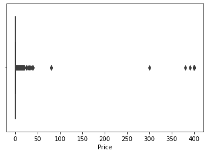

```python
sns.boxplot(df_sanity['Price'])
```

The above plot shows outlier as price of some apps are high as compare to others

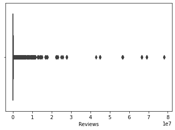

```python
sns.boxplot(df_sanity['Reviews'])
```

The above plot shows that some app have higher review

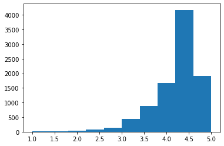

```python
plt.hist(df_sanity['Rating'])
```

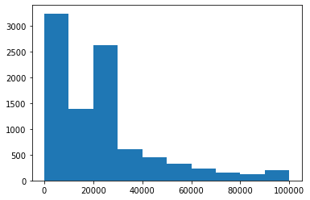

```python
plt.hist(df_sanity['Size'])
```

# Outlier Treatment

```python
df_outlier = df_sanity.copy()
```

Dropping records where price is very high. These apps are not required.

```python
df_outlier1 = df_outlier[(df_outlier['Price'] >= 200) ].index
df_outlier1
```

```
Int64Index([4197, 4362, 4367, 5351, 5354, 5355, 5356, 5357, 5358, 5359, 5362,
            5364, 5366, 5369, 5373],
           dtype='int64')
```

```python
df_outlier.drop(df_outlier1, inplace=True)
```

```python
df_outlier.shape
```

```
(9338, 13)
```

Drop records having more than 2 million reviews as it skews the graph.

```python
df_outlier2 = df_outlier[(df_outlier['Reviews'] > 2000000) ].index
df_outlier2
```

```
Int64Index([  139,   335,   336,   338,   340,   341,   342,   344,   345,
              347,
            ...
             8658,  8894,  8896,  9140,  9142,  9166,  9841, 10186, 10190,
            10327],
           dtype='int64', length=453)
```

```python
df_outlier.drop(df_outlier2, inplace = True)
```

```python
df_outlier.shape
```

```
(8885, 13)
```

Install field is holding some outliers. Apps having very high number of installs should be dropped from the analysis.

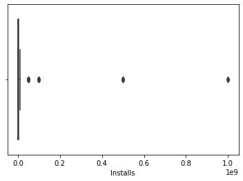

```python
sns.boxplot(df_outlier['Installs'])
```

```python
df_outlier.Installs.describe()
```

```
count    8.885000e+03
mean     6.267379e+06
std      3.539960e+07
min      5.000000e+00
25%      1.000000e+04
50%      5.000000e+05
75%      5.000000e+06
max      1.000000e+09
Name: Installs, dtype: float64
```

```python
df_outlier.Installs.quantile([0.1, 0.25, 0.5, 0.7, 0.9, 0.95, 0.99])
```

```
0.10         1000.0
0.25        10000.0
0.50       500000.0
0.70      1000000.0
0.90     10000000.0
0.95     10000000.0
0.99    100000000.0
Name: Installs, dtype: float64
```

```python
df_outlier3 = df_outlier[(df_outlier['Installs'] >  100000000)].index
df_outlier3
```

```
Int64Index([ 152, 3265, 3326, 3473, 3476, 3533, 3562, 3569, 3574, 3687, 3736,
            3755, 3765, 3767, 3816, 3819, 4048, 4147, 5596, 9844],
           dtype='int64')
```

```python
df_outlier.drop(df_outlier3, inplace = True)
```

```python
df_outlier.shape
```

```
(8865, 13)
```

# Bivariate Analysis

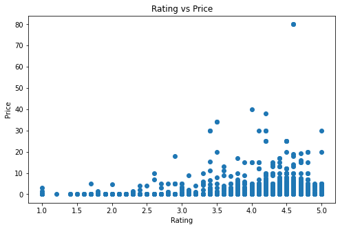

```python
plt.figure(figsize=(8,5))
plt.scatter(df_outlier['Rating'], df_outlier['Price'])
plt.title('Rating vs Price')
plt.xlabel('Rating')
plt.ylabel('Price')
```

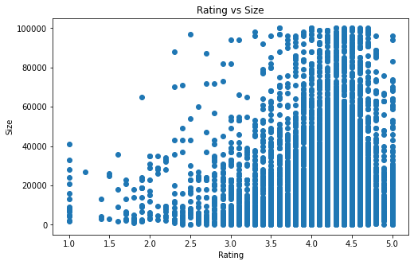

```python
plt.figure(figsize=(8,5))
plt.scatter(df_outlier['Rating'],df_outlier['Size'])
plt.title('Rating vs Size')
plt.xlabel('Rating')
plt.ylabel('Size')
```

The plot shows that rating is high for app with large size.

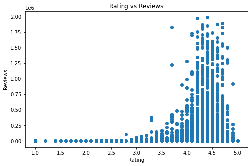

```python
plt.figure(figsize=(8,5))
plt.scatter(df_outlier['Rating'],df_outlier['Reviews'])
plt.title('Rating vs Reviews')
plt.xlabel('Rating')
plt.ylabel('Reviews')
```

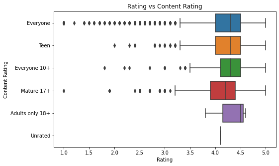

```python
plt.figure(figsize=(8,5))
sns.boxplot(df_outlier['Rating'],df_outlier['Content Rating'])
plt.title('Rating vs Content Rating')
plt.xlabel('Rating')
plt.ylabel('Content Rating')
```

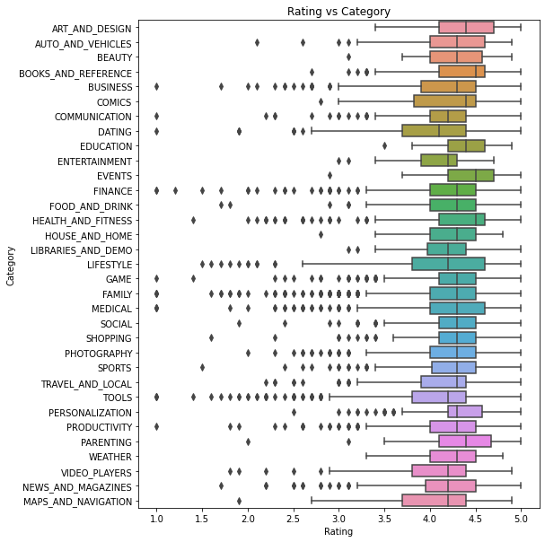

```python
plt.figure(figsize=(8,10))
sns.boxplot(df_outlier['Rating'],df_outlier['Category'])
plt.title('Rating vs Category')
plt.xlabel('Rating')
plt.ylabel('Category')
```

# Data Preprocessing

```python
inp1 = df_outlier.copy()
```

```python
inp1.shape
```

```
(8865, 13)
```

Reviews and Install have some values that are still relatively very high. Skewness should be removed before building the linear model using log transformation

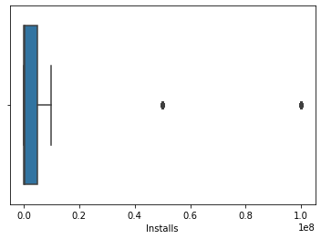

```python
sns.boxplot(inp1.Installs)
```

```python
inp1['Installs'] = inp1.Installs.apply(np.log1p)
```

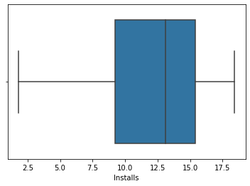

```python
sns.boxplot(inp1['Installs'])
```

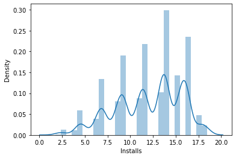

```python
sns.distplot(inp1.Installs)
```

```python
inp1['Reviews'] = np.log1p(inp1['Reviews'])
```

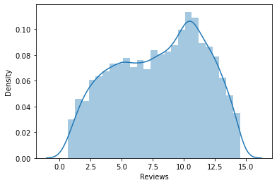

```python
sns.distplot(inp1['Reviews'])
```

```python
inp1.info()
```

```
<class 'pandas.core.frame.DataFrame'>
Int64Index: 8865 entries, 0 to 10840
Data columns (total 13 columns):
 #   Column          Non-Null Count  Dtype
---  ------          --------------  -----
 0   App             8865 non-null   object
 1   Category        8865 non-null   object
 2   Rating          8865 non-null   float64
 3   Reviews         8865 non-null   float64
 4   Size            8865 non-null   float64
 5   Installs        8865 non-null   float64
 6   Type            8865 non-null   object
 7   Price           8865 non-null   float64
 8   Content Rating  8865 non-null   object
 9   Genres          8865 non-null   object
 10  Last Updated    8865 non-null   object
 11  Current Ver     8865 non-null   object
 12  Android Ver     8865 non-null   object
dtypes: float64(5), object(8)
memory usage: 1.2+ MB
```

Dropping fields App, Last Updated, Current Ver and Android Ver as not required for further analysis

```python
inp1.drop(['App','Last Updated','Current Ver','Android Ver'], axis = 1, inplace = True )
```

```python
inp1.shape
```

```
(8865, 9)
```

Get dummy columns for Category, Type, Genres and Content Rating as the models do not understand categorical data so it should be converted to numeric

```python
inp2 = pd.get_dummies(inp1, columns=['Category','Type','Content Rating','Genres'], drop_first = True)
```

```python
inp2.columns
```

```
Index(['Rating', 'Reviews', 'Size', 'Installs', 'Price',
       'Category_AUTO_AND_VEHICLES', 'Category_BEAUTY',
       'Category_BOOKS_AND_REFERENCE', 'Category_BUSINESS', 'Category_COMICS',
       ...
       'Genres_Tools', 'Genres_Tools;Education', 'Genres_Travel & Local',
       'Genres_Travel & Local;Action & Adventure', 'Genres_Trivia',
       'Genres_Video Players & Editors',
       'Genres_Video Players & Editors;Creativity',
       'Genres_Video Players & Editors;Music & Video', 'Genres_Weather',
       'Genres_Word'],
      dtype='object', length=157)
```

# Train-test split

Applying 70-30 split to dataframe where 70% is train data and 30% is test data

```python
df_train, df_test = train_test_split(inp2, train_size = 0.7, random_state = 100)
```

```python
df_train.shape , df_test.shape
```

```
((6205, 157), (2660, 157))
```

Seprating dataframe into X_train , X_test, y_train, y_test where y is the response variable

```python
y_train = df_train.pop('Rating')
X_train = df_train
y_test = df_test.pop('Rating')
X_test = df_test
```

Linear Regression Model Building

```python
lm = LinearRegression()
lm.fit(X_train, y_train)
```

```
LinearRegression()
```

```python
pred_train = lm.predict(X_train)
pred_test = lm.predict(X_test)
```

Evaluation of the model for train data

```python
mse_train = mean_squared_error(y_train, pred_train)
rmse_train = sqrt(mse_train)
print("Mean Square error for train data is :", mse_train)
print("Root Mean Square error for train data is :", rmse_train)
r2_train = r2_score(y_train, pred_train)
print('R2 value of Model on train data:', r2_train)
```

```
Mean Square error for train data is : 0.2283882415997311
Root Mean Square error for train data is : 0.47789982381219925
R2 value of Model on train data: 0.16332652859405272
```

Evaluation of model for test data

```python
mse_test = mean_squared_error(y_test, pred_test)
rmse_test = sqrt(mse_test)
print("Mean Square error for test data is :", mse_test)
print("Root Mean Square error for test data is :", rmse_test)
r2_test = r2_score(y_test, pred_test)
print('R2 value of Model on test data:', r2_test)
```

```
Mean Square error for test data is : 0.2406698189586998
Root Mean Square error for test data is : 0.4905811033444927
R2 value of Model on test data: 0.13976031635216568
```

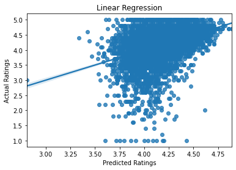

```python
sns.regplot(pred_train,y_train)
plt.title('Linear Regression')
plt.xlabel('Predicted Ratings')
plt.ylabel('Actual Ratings')
```

Regression plot for Predicted rating vs Actual rating on test data

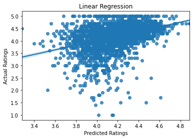

```python
sns.regplot(pred_test,y_test)
plt.title('Linear Regression')
plt.xlabel('Predicted Ratings')
plt.ylabel('Actual Ratings')
```